# 2003 Intermediate Quantitative Methods

Assignment 0

Tong Jin

08/31/2019

```r
# Read in data
height <- read.csv("height_sex.csv")

# Inspect the first few rows
height[1:5, ]
```

|  | X | id | Gender | Birth.Order | Height | Weight | Male |
| --- | --- | --- | --- | --- | --- | --- | --- |
| 1 | 1 | 1 | M | 1 | 65.44441 | 166.14611 | 1 |
| 2 | 2 | 2 | F | 2 | 65.44836 | 76.74407 | 0 |
| 3 | 3 | 3 | M | 2 | 68.39149 | 140.14253 | 1 |
| 4 | 4 | 4 | M | 1 | 73.92210 | 165.30409 | 1 |
| 5 | 5 | 5 | F | 1 | 70.98392 | 117.61932 | 0 |

1. The mean height of men is calculated below and saved as MM. Fill in the rest of the code to
1. save the mean height of women as MW and
2. print the mean height of women

```r
# mean height of men
MM <- mean(height$Height[height$Male == 1])

# print mean height of men
print(MM)
```

```
## [1] 69.55706
```

```r
# mean height of women
MW <- mean(height$Height[height$Male == 0])

# print mean height of women
print(MW)
```

```
## [1] 65.726
```

2. Calculate the mean difference for the two groups and plot the regression line
1. Save and print: MeanDiff = MM - MW
2. Add (0, MW) and (1,MM) to the plot from above (in yellow)
3. Draw a line connecting (0, MW) and (1,MM) using the abline() function

```r
# the difference in means (MM - MW)
MeanDiff <- MM - MW

# print MeanDiff
print(MeanDiff)
```

```
## [1] 3.831066
```

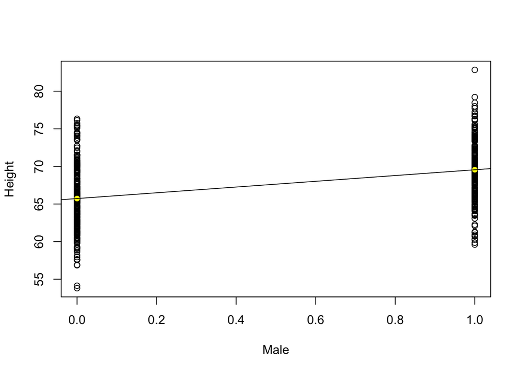

```r
# re-plot the data
plot(height$Male, height$Height, xlab = "Male", ylab = "Height")

# add (0, MW) to the plot (in yellow)
points(0, MW, col = 7, pch = 16)

# note: pch=16 makes the dot filled in, which makes it easier to see
points(1, MM, col = 7, pch = 16)

# draw the line Height=b_0 + b_1*Male where b_0=MW and b_1=MeanDiff
abline(a = MW, b = MeanDiff, untf = FALSE)
```

3. Estimate the standard error for an independent sample T-test by hand (note: assume pooled standard deviation)
1. Calculate nM and nW, the number of men and women in the sample, respectively
2. Calculate sM and sW, the sample standard deviations for the men’s heights and women’s heights, respectively
3. Calculate $s_{pooled}$ for the two groups using $s_{pooled}=\sqrt{\frac{s_1^2(n_1-1)+s_2^2(n_2-1)}{n_1+n_2-2}}$ and save the result as spool
4. Use the following equation: $SE(\bar{x_1}-\bar{x_2})=\sqrt{\frac{s_1^2}{n_1}+\frac{s_2^2}{n_2}}$ to estimate $SE(\bar{x_1}-\bar{x_2})$ where $s_1=s_2=s_{pooled}$ and $n_1=nW$, $n_2=nM$. Save the result as SEMeanDiff and print the result.

```r
# add code to calculate the number of women and save the result as nW
nM <- length(height$Height[height$Male == 1])
nW <- length(height$Height[height$Male == 0])

# add code to calculate sW, the sample standard deviation for women's
# heights
sM <- sd(height$Height[height$Male == 1])
sW <- sd(height$Height[height$Male == 0])

# calculate pooled standard deviation and save as spool (note: sqrt()
# calculates square root)
dFreedom <- nW + nM - 2
spool <- sqrt((sM^2 * (nM - 1) + sW^2 * (nW - 1))/dFreedom)

# print spool
print(spool)
```

```
## [1] 4.129775
```

```r
# estimate the standard error of the difference in means and save it as
# SEMeanDiff
SEMeanDiff <- sqrt((spool^2/nW) + (spool^2/nM))

# print SEMeanDiff
print(SEMeanDiff)
```

```
## [1] 0.3695232
```

4. Calculate a T-Statistic by hand to compare the null hypothesis that $MM-MW=0$ versus the alternative hypothesis that $MM-MW\ne0$
1. Calculate $T=\frac{(\text{MeanDiff})-0}{\text{SEMeanDiff}}$ and save the result as Ttest
2. Use the pt function to calculate a p-value for Ttest (degrees freedom= nW+nM-2). Hint: You will want to use the parameter lower.tail=FALSE because Ttest should be $>0$ for this example, then multiply by 2 to get a 2-sided test

```r
# calculate a test statistic and save it as Ttest
Ttest <- (MeanDiff - 0)/SEMeanDiff

# print Ttest
print(Ttest)
```

```
## [1] 10.36759
```

```r
# use pt to calculate a p-value
p_value <- 2 * pt(Ttest, df = dFreedom, lower.tail = FALSE)
print(p_value)
```

```
## [1] 6.173822e-23
```

5. Do the same thing using the t.test() function in R. Compare the value of t and p-value computed by the t.test() function to the values you calculated above. Note that setting var.equal=TRUE causes t.test() to use pooled variance. Do you get the same value (to two decimal places) for the T statistic?

```r
# use the t.test function to compare the men's heights and female's heights
t.test(height$Height[height$Male == 1], height$Height[height$Male == 0], var.equal = TRUE)
```

```
##
##  Two Sample t-test
##
## data:  height$Height[height$Male == 1] and height$Height[height$Male == 0]
## t = 10.368, df = 498, p-value < 2.2e-16
## alternative hypothesis: true difference in means is not equal to 0
## 95 percent confidence interval:
##  3.105049 4.557082
## sample estimates:
## mean of x mean of y
##  69.55706  65.72600
```

```r
## the value of Ttest and the t-value in the t.test are the same (to two
## decimal places).
```

6. Use the lm() function to implement ordinary least squares regression to estimate $\beta_0$ and $\beta_1$ in the equation $Height=\beta_0+\beta_1*Male$.

```r
# use lm() to estimate b_0 and b_1 in the equation Height=b_0+b_1*Male; save
# the result as linmod
linmod <- lm(Height ~ Male, data = height)

# inspect a summary of the results using the summary() function on linmod
summary(linmod)
```

```
##
## Call:
## lm(formula = Height ~ Male, data = height)
##
## Residuals:
##     Min      1Q  Median      3Q     Max
## -11.919  -2.957  -0.076   2.607  13.275
##
## Coefficients:
##             Estimate Std. Error t value Pr(>|t|)
## (Intercept)  65.7260     0.2576  255.14   <2e-16 ***
## Male          3.8311     0.3695   10.37   <2e-16 ***
## ---
## Signif. codes:  0 '***' 0.001 '**' 0.01 '*' 0.05 '.' 0.1 ' ' 1
##
## Residual standard error: 4.13 on 498 degrees of freedom
## Multiple R-squared:  0.1775, Adjusted R-squared:  0.1759
## F-statistic: 107.5 on 1 and 498 DF,  p-value: < 2.2e-16
```

7. Reprint the following values that you saved in previous problems: Mean women’s height (MW), difference in mean height for men and women (MeanDiff), standard error of this mean difference (SEMeanDiff), and the T statistic for the difference in means (Ttest). Which of these values can you find in the lm() output above?

```r
# re-print MW
print(MW)
```

```
## [1] 65.726
```

```r
# re-print MeanDiff
print(MeanDiff)
```

```
## [1] 3.831066
```

```r
# re-print SEMeandiff
print(SEMeanDiff)
```

```
## [1] 0.3695232
```

```r
# re-print Ttest
print(Ttest)
```

```
## [1] 10.36759
```

8. Note that the T-test for the intercept in the lm() output above tests the null hypothesis: $\beta_0=0$ against the alternative hypothesis: $\beta_0\ne 0$. In the space below, please show how you could calculate the Std. Error (.2576) and the t value (255.14) of the intercept without using lm() or t.test(). Hint: lm() uses $s_{pooled}$ to estimate the standard deviation of heights for both groups.

```r
# Estimate standard error of b_0

## according to the central limit theorem, the mean of a sampling
## distribution of means is an unbiased estimator of the population mean
SEb_0 <- (spool/sqrt(nW))
print(SEb_0)
```

```
## [1] 0.2576083
```

```r
# Use the standard error of b_0 to calculate the t value
tH_0 <- (MW - 0)/SEb_0
print(tH_0)
```

```
## [1] 255.1393
```